# Goodreads Data Analysis

### An analysis of the top ten thousand "most frequently rated" books on Goodreads.

##### By Benjamin Skopets

I was motivated to analyze this dataset because I was an avid reader for many years of my life, and still love reading. I loved books such as Sociology/Economics books written by Stephen Dubner, Steven Levitt, and Malcolm Gladwell. I was shocked to learn a few years ago that despite the fact that I thought these books were incredibly well written, provided thought-provoking insights into how life and business works behind the scenes, and were entertaining, they received only 4 star average reviews on Goodreads, instead of the 4.7+ star average reviews I had expected. This made me curious about the psychology of rating books itself, which drew me to this dataset. Hopefully, any readers will be curious about how their favorite books are rated on Goodreads, and overall trends that can be found by analyzing publicly available data about Goodreads book reviews.

[figure not shown]

```python
import pandas as pd
import warnings


warnings.filterwarnings("ignore")

r = pd.read_csv( 'ratings.csv' )
tr = pd.read_csv( 'to_read.csv' )
b = pd.read_csv( 'books.csv' )

t = pd.read_csv( 'tags.csv' )
bt = pd.read_csv( 'book_tags.csv')
```

First let's look at our main dataset that we will be working with. This dataset contains information about each of the top ten thousand most rated books on Goodreads. It contains each book's title, average rating, the number of 1,2,3,4 and 5-star reviews each book received, its publication date, authors, publication year, and other relevant information.

```python
b
```

|  | book_id | goodreads_book_id | best_book_id | work_id | books_count | isbn | isbn13 | authors | original_publication_year | original_title | ... | ratings_count | work_ratings_count | work_text_reviews_count | ratings_1 | ratings_2 | ratings_3 | ratings_4 | ratings_5 | image_url | small_image_url |
| --- | --- | --- | --- | --- | --- | --- | --- | --- | --- | --- | --- | --- | --- | --- | --- | --- | --- | --- | --- | --- | --- |
| 0 | 1 | 2767052 | 2767052 | 2792775 | 272 | 439023483 | 9.780439e+12 | Suzanne Collins | 2008.0 | The Hunger Games | ... | 4780653 | 4942365 | 155254 | 66715 | 127936 | 560092 | 1481305 | 2706317 | https://images.gr-assets.com/books/1447303603m... | https://images.gr-assets.com/books/1447303603s... |
| 1 | 2 | 3 | 3 | 4640799 | 491 | 439554934 | 9.780440e+12 | J.K. Rowling, Mary GrandPré | 1997.0 | Harry Potter and the Philosopher's Stone | ... | 4602479 | 4800065 | 75867 | 75504 | 101676 | 455024 | 1156318 | 3011543 | https://images.gr-assets.com/books/1474154022m... | https://images.gr-assets.com/books/1474154022s... |
| 2 | 3 | 41865 | 41865 | 3212258 | 226 | 316015849 | 9.780316e+12 | Stephenie Meyer | 2005.0 | Twilight | ... | 3866839 | 3916824 | 95009 | 456191 | 436802 | 793319 | 875073 | 1355439 | https://images.gr-assets.com/books/1361039443m... | https://images.gr-assets.com/books/1361039443s... |
| 3 | 4 | 2657 | 2657 | 3275794 | 487 | 61120081 | 9.780061e+12 | Harper Lee | 1960.0 | To Kill a Mockingbird | ... | 3198671 | 3340896 | 72586 | 60427 | 117415 | 446835 | 1001952 | 1714267 | https://images.gr-assets.com/books/1361975680m... | https://images.gr-assets.com/books/1361975680s... |
| 4 | 5 | 4671 | 4671 | 245494 | 1356 | 743273567 | 9.780743e+12 | F. Scott Fitzgerald | 1925.0 | The Great Gatsby | ... | 2683664 | 2773745 | 51992 | 86236 | 197621 | 606158 | 936012 | 947718 | https://images.gr-assets.com/books/1490528560m... | https://images.gr-assets.com/books/1490528560s... |
| ... | ... | ... | ... | ... | ... | ... | ... | ... | ... | ... | ... | ... | ... | ... | ... | ... | ... | ... | ... | ... | ... |
| 9995 | 9996 | 7130616 | 7130616 | 7392860 | 19 | 441019455 | 9.780441e+12 | Ilona Andrews | 2010.0 | Bayou Moon | ... | 17204 | 18856 | 1180 | 105 | 575 | 3538 | 7860 | 6778 | https://images.gr-assets.com/books/1307445460m... | https://images.gr-assets.com/books/1307445460s... |
| 9996 | 9997 | 208324 | 208324 | 1084709 | 19 | 067973371X | 9.780680e+12 | Robert A. Caro | 1990.0 | Means of Ascent | ... | 12582 | 12952 | 395 | 303 | 551 | 1737 | 3389 | 6972 | https://s.gr-assets.com/assets/nophoto/book/11... | https://s.gr-assets.com/assets/nophoto/book/50... |
| 9997 | 9998 | 77431 | 77431 | 2393986 | 60 | 039330762X | 9.780393e+12 | Patrick O'Brian | 1977.0 | The Mauritius Command | ... | 9421 | 10733 | 374 | 11 | 111 | 1191 | 4240 | 5180 | https://images.gr-assets.com/books/1455373531m... | https://images.gr-assets.com/books/1455373531s... |
| 9998 | 9999 | 8565083 | 8565083 | 13433613 | 7 | 61711527 | 9.780062e+12 | Peggy Orenstein | 2011.0 | Cinderella Ate My Daughter: Dispatches from th... | ... | 11279 | 11994 | 1988 | 275 | 1002 | 3765 | 4577 | 2375 | https://images.gr-assets.com/books/1279214118m... | https://images.gr-assets.com/books/1279214118s... |
| 9999 | 10000 | 8914 | 8914 | 11817 | 31 | 375700455 | 9.780376e+12 | John Keegan | 1998.0 | The First World War | ... | 9162 | 9700 | 364 | 117 | 345 | 2031 | 4138 | 3069 | https://images.gr-assets.com/books/1403194704m... | https://images.gr-assets.com/books/1403194704s... |

10000 rows × 23 columns

The first analysis I performed out of curiosity was: was there a significant correlation between year and average average review - yes, "average" should appear there twice - for that year. In other words, did Goodreads users tend to rate older books as better or worse than modern books, or was there no significant relationship to be found?

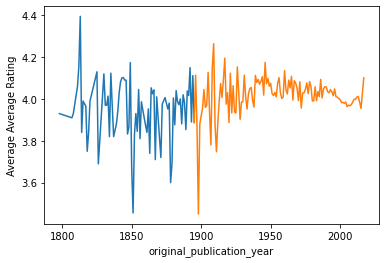

```python
avgPerYear = b.groupby( 'original_publication_year' ).average_rating.mean()

avgPerYear19thCentury = avgPerYear.iloc[95:171]

avgPerYear19thCentury.plot.line(x = "original_publication_year", y = "average_rating", ylabel = 'Average Average Rating')

avgPerYearSince1900 = avgPerYear.iloc[170:]

avgPerYearSince1900.plot.line(x = "original_publication_year", y = "average_rating", ylabel = 'Average Average Rating')
```

As one can tell, there is very little relationship between the year and average average book rating for that year. The original dataset of books had books going back to 1750 B.C.E., which I felt were outliers that complicated data analysis and interpretation, so I removed them by only keeping books that were published after 1800. This only removed 2% of the books in the original dataset.

Next, I show books published in the year 1813 in our dataset and their average ratings to demonstrate why "spikes" exist in the above graph, i.e years in which the average average book rating was far from the norm of 4.0. What we find is that these years with "spikes" in the graph had very few books published and in our dataset, and their average average rating was far from the norm.

```python
# The "9" to the right of the book with the 4.24 average rating means that it is the 9th most reviewed book
# on GoodReads. This book happens to be "Pride and Prejudice" by Jane Austen.

# The data entries from this year show how a relatively small number of books in a given year can lead to
# an average "average rating" that is quite different from the norm of ~4.05.
b.loc[b["original_publication_year"] == 1813][['average_rating', 'title', 'authors']]
```

|  | average_rating | title | authors |
| --- | --- | --- | --- |
| 9 | 4.24 | Pride and Prejudice | Jane Austen |
| 4652 | 4.55 | The Complete Novels | Jane Austen |

```python
# Some columns are dropped from the "Books published since 1800" dataset to make it easier to interpret and to remove unnecessary data.
booksSince1800 = b.loc[b["original_publication_year"] > 1800]
booksSince1800 = booksSince1800.drop(columns = ["goodreads_book_id","best_book_id","work_id", "isbn","isbn13","image_url","small_image_url"])
```

## Alphabetical By First Name, Last Name, and Book Title - Analysis

Next, I was curious about whether any relationship existed between the first letter of the author's first name on the one hand and the number of reviews that author's book(s) received and the average review the book(s) received on the other hand. I therefore sorted my dataset alphabetically by first name using Pandas's sort_values function. I then created scatterplots to show these relationships and fitted a regression line to them to see if any significant positive or negative correlation existed between them.

The graphs can be interpreted as follows: the more to the left a datapoint appears, the earlier in the alphabet the first letter of an author's furst name is. The more to the right a datapoint appears, the later in the alphabet the first letter of an author's furst name is.

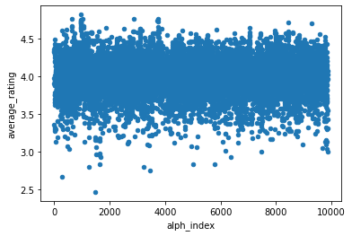

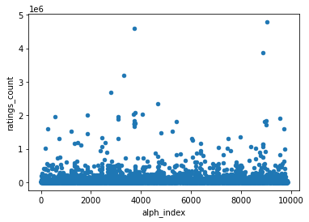

```python
alphabeticalByFirstName = booksSince1800.sort_values('authors')
alphabeticalByFirstName["alph_index"] = alphabeticalByFirstName.reset_index().index
alphabeticalByFirstName.plot.scatter(x = 'alph_index', y = "average_rating")
alphabeticalByFirstName.plot.scatter(x = 'alph_index', y = "ratings_count")
```

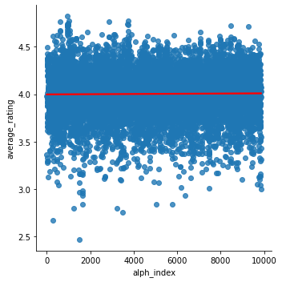

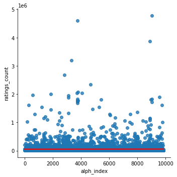

```python
# Fitting regression lines onto the two graphs using Seaborn's lmplot and fit_reg function and argument.

import seaborn as sns
sns.lmplot(x='alph_index', y='average_rating',data=alphabeticalByFirstName, fit_reg=True, line_kws={'color': 'red'})
sns.lmplot(x='alph_index', y='ratings_count',data=alphabeticalByFirstName, fit_reg=True, line_kws={'color': 'red'})
```

```python
# Out of curiosity, I wanted to know how many of the books in the dataset have multiple authors.
# I used the .loc functionality of the Pandas Dataframe and found that roughly 20% of the books in our
# dataframe have more than one author.
multiAuthorBooks = booksSince1800.loc[booksSince1800["authors"].str.contains(",")]
multiAuthorBooks
```

|  | book_id | books_count | authors | original_publication_year | original_title | title | language_code | average_rating | ratings_count | work_ratings_count | work_text_reviews_count | ratings_1 | ratings_2 | ratings_3 | ratings_4 | ratings_5 |
| --- | --- | --- | --- | --- | --- | --- | --- | --- | --- | --- | --- | --- | --- | --- | --- | --- |
| 1 | 2 | 491 | J.K. Rowling, Mary GrandPré | 1997.0 | Harry Potter and the Philosopher's Stone | Harry Potter and the Sorcerer's Stone (Harry P... | eng | 4.44 | 4602479 | 4800065 | 75867 | 75504 | 101676 | 455024 | 1156318 | 3011543 |
| 12 | 13 | 995 | George Orwell, Erich Fromm, Celâl Üster | 1949.0 | Nineteen Eighty-Four | 1984 | eng | 4.14 | 1956832 | 2053394 | 45518 | 41845 | 86425 | 324874 | 692021 | 908229 |
| 14 | 15 | 710 | Anne Frank, Eleanor Roosevelt, B.M. Mooyaart-D... | 1947.0 | Het Achterhuis: Dagboekbrieven 14 juni 1942 - ... | The Diary of a Young Girl | eng | 4.10 | 1972666 | 2024493 | 20825 | 45225 | 91270 | 355756 | 656870 | 875372 |
| 15 | 16 | 274 | Stieg Larsson, Reg Keeland | 2005.0 | Män som hatar kvinnor | The Girl with the Dragon Tattoo (Millennium, #1) | eng | 4.11 | 1808403 | 1929834 | 62543 | 54835 | 86051 | 285413 | 667485 | 836050 |
| 17 | 18 | 376 | J.K. Rowling, Mary GrandPré, Rufus Beck | 1999.0 | Harry Potter and the Prisoner of Azkaban | Harry Potter and the Prisoner of Azkaban (Harr... | eng | 4.53 | 1832823 | 1969375 | 36099 | 6716 | 20413 | 166129 | 509447 | 1266670 |
| ... | ... | ... | ... | ... | ... | ... | ... | ... | ... | ... | ... | ... | ... | ... | ... | ... |
| 9968 | 9969 | 67 | Giulia Enders, Jill Enders | 2014.0 | Darm mit Charme | Gut: The Inside Story of Our Body’s Most Under... | eng | 3.99 | 5973 | 12156 | 1394 | 92 | 452 | 2588 | 5329 | 3695 |
| 9972 | 9973 | 52 | John M. Gottman, Nan Silver | 1999.0 | The Seven Principles for Making Marriage Work:... | The Seven Principles for Making Marriage Work:... | NaN | 4.19 | 8868 | 10017 | 749 | 126 | 334 | 1604 | 3446 | 4507 |
| 9977 | 9978 | 70 | Yukio Mishima, John Nathan | 1963.0 | 午後の曳航 [Gogo no eikō] | The Sailor Who Fell from Grace with the Sea | en-US | 3.89 | 8810 | 10541 | 755 | 142 | 590 | 2414 | 4551 | 2844 |
| 9984 | 9985 | 24 | Steve Perry, Tom Clancy, Steve Pieczenik | 2000.0 | Tom Clancy's Net Force: Breaking Point | Breaking Point (Tom Clancy's Net Force, #4) | eng | 3.69 | 7693 | 7825 | 26 | 268 | 684 | 2349 | 2456 | 2068 |
| 9993 | 9994 | 2 | Michael Buckley, Peter Ferguson | 2009.0 | The Everafter War (The Sisters Grimm, #7) | The Everafter War (The Sisters Grimm, #7) | eng | 4.32 | 12493 | 12965 | 455 | 110 | 289 | 1745 | 3989 | 6832 |

1983 rows × 16 columns

I wanted to perform the exact same analysis I performed on the first letter of an author's first name, but this time do it on the first letter of the author's last name and the first letter of the title of the book. The next few graphs demonstrate exactly this.

```python
# To make sorting by last name less problematic, I made a separate Pandas Dataframe to store only
# single-author books, all of which were published since 1800.
singleAuthorBooksSince1800 = booksSince1800.loc[booksSince1800["authors"].str.contains(",") == False]
singleAuthorBooksSince1800
```

|  | book_id | books_count | authors | original_publication_year | original_title | title | language_code | average_rating | ratings_count | work_ratings_count | work_text_reviews_count | ratings_1 | ratings_2 | ratings_3 | ratings_4 | ratings_5 |
| --- | --- | --- | --- | --- | --- | --- | --- | --- | --- | --- | --- | --- | --- | --- | --- | --- |
| 0 | 1 | 272 | Suzanne Collins | 2008.0 | The Hunger Games | Hunger Games (Hunger Games, #1) | eng | 4.34 | 4780653 | 4942365 | 155254 | 66715 | 127936 | 560092 | 1481305 | 2706317 |
| 2 | 3 | 226 | Stephenie Meyer | 2005.0 | Twilight | Twilight (Twilight, #1) | en-US | 3.57 | 3866839 | 3916824 | 95009 | 456191 | 436802 | 793319 | 875073 | 1355439 |
| 3 | 4 | 487 | Harper Lee | 1960.0 | To Kill a Mockingbird | To Kill a Mockingbird | eng | 4.25 | 3198671 | 3340896 | 72586 | 60427 | 117415 | 446835 | 1001952 | 1714267 |
| 4 | 5 | 1356 | F. Scott Fitzgerald | 1925.0 | The Great Gatsby | Great Gatsby | eng | 3.89 | 2683664 | 2773745 | 51992 | 86236 | 197621 | 606158 | 936012 | 947718 |
| 5 | 6 | 226 | John Green | 2012.0 | The Fault in Our Stars | Fault in Our Stars | eng | 4.26 | 2346404 | 2478609 | 140739 | 47994 | 92723 | 327550 | 698471 | 1311871 |
| ... | ... | ... | ... | ... | ... | ... | ... | ... | ... | ... | ... | ... | ... | ... | ... | ... |
| 9995 | 9996 | 19 | Ilona Andrews | 2010.0 | Bayou Moon | Bayou Moon (Edge, #2) | eng | 4.09 | 17204 | 18856 | 1180 | 105 | 575 | 3538 | 7860 | 6778 |
| 9996 | 9997 | 19 | Robert A. Caro | 1990.0 | Means of Ascent | Means of Ascent (Years of Lyndon Johnson, #2) | eng | 4.25 | 12582 | 12952 | 395 | 303 | 551 | 1737 | 3389 | 6972 |
| 9997 | 9998 | 60 | Patrick O'Brian | 1977.0 | The Mauritius Command | Mauritius Command | eng | 4.35 | 9421 | 10733 | 374 | 11 | 111 | 1191 | 4240 | 5180 |
| 9998 | 9999 | 7 | Peggy Orenstein | 2011.0 | Cinderella Ate My Daughter: Dispatches from th... | Cinderella Ate My Daughter: Dispatches from th... | eng | 3.65 | 11279 | 11994 | 1988 | 275 | 1002 | 3765 | 4577 | 2375 |
| 9999 | 10000 | 31 | John Keegan | 1998.0 | The First World War | First World War | NaN | 4.00 | 9162 | 9700 | 364 | 117 | 345 | 2031 | 4138 | 3069 |

7871 rows × 16 columns

```python
pd.options.mode.chained_assignment = None

surnames = pd.Series(singleAuthorBooksSince1800["authors"], dtype="string")
singleAuthorBooksSince1800["author_surname"] = surnames

singleAuthorBooksSince1800["author_surname"] = singleAuthorBooksSince1800["author_surname"].str.split().str[-1]
singleAuthorBooksSince1800["author_surname"]
```

```
0          Collins
2            Meyer
3              Lee
4       Fitzgerald
5            Green
           ...
9995       Andrews
9996          Caro
9997       O'Brian
9998     Orenstein
9999        Keegan
Name: author_surname, Length: 7871, dtype: object
```

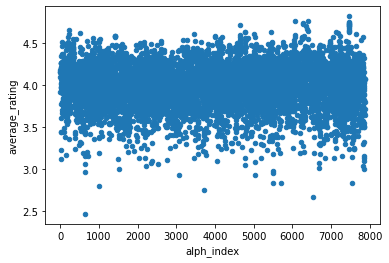

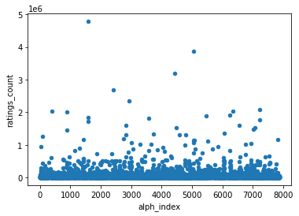

```python
alphabeticalBySurname = singleAuthorBooksSince1800.sort_values('author_surname')
alphabeticalBySurname["alph_index"] = alphabeticalBySurname.reset_index().index
alphabeticalBySurname.plot.scatter(x = 'alph_index', y = "average_rating")
alphabeticalBySurname.plot.scatter(x = 'alph_index', y = "ratings_count")
```

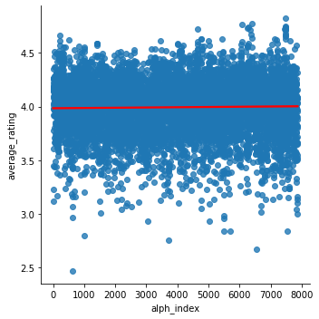

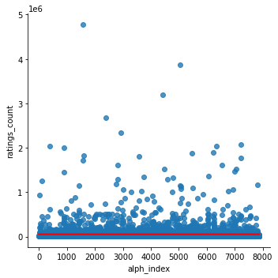

```python
# Fitting regression lines onto the two graphs using Seaborn's lmplot and fit_reg function and argument.
sns.lmplot(x='alph_index', y='average_rating',data=alphabeticalBySurname, fit_reg=True, line_kws={'color': 'red'})
sns.lmplot(x='alph_index', y='ratings_count',data=alphabeticalBySurname, fit_reg=True, line_kws={'color': 'red'})
```

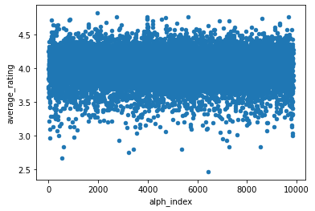

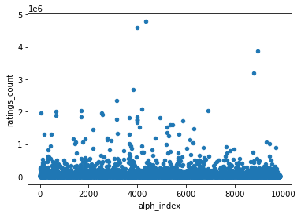

```python
alphabeticalByTitle = booksSince1800

# Getting rid of the word "The " if it appears as the first word of a title. This is because, typically
# when book titles are displayed in alphabetical order, the word "The " is ignored if it is the first word.
alphabeticalByTitle['title'] = alphabeticalByTitle['title'].str.replace('The ','')

alphabeticalByTitle = alphabeticalByTitle.sort_values('title')
alphabeticalByTitle["alph_index"] = alphabeticalByTitle.reset_index().index
alphabeticalByTitle.plot.scatter(x = 'alph_index', y = "average_rating")
alphabeticalByTitle.plot.scatter(x = 'alph_index', y = "ratings_count")
```

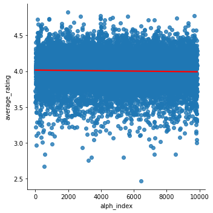

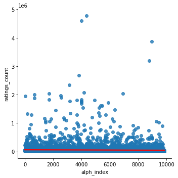

```python
sns.lmplot(x='alph_index', y='average_rating',data=alphabeticalByTitle, fit_reg=True, line_kws={'color': 'red'})
sns.lmplot(x='alph_index', y='ratings_count',data=alphabeticalByTitle, fit_reg=True, line_kws={'color': 'red'})
```

### Results

As one can see, there appears to be no significant relationship between these variables whatsoever. However, I thought that if the top 1,000 most reviewed books are analyzed instead of the top 10,000, perhaps a correlation will appear. The next few graphs demonstrate this once again, using a very similar process as before. I thought a relationship between these variables may appear since it is a known fact that Nobel Prize winners and tenured professors are overrepresented if their last name comes early alphabetically. This is because scientific papers often have their authors listen in alphabetical order, and sometimes only the first author is mentioned, such as Bentley et. al.

```python
# The top 1000 most reviewed books written since 1800 are put into a single dataset for analysis.
top1000BooksSince1800 = booksSince1800.iloc[:1000]
top1000BooksSince1800
```

|  | book_id | books_count | authors | original_publication_year | original_title | title | language_code | average_rating | ratings_count | work_ratings_count | work_text_reviews_count | ratings_1 | ratings_2 | ratings_3 | ratings_4 | ratings_5 |
| --- | --- | --- | --- | --- | --- | --- | --- | --- | --- | --- | --- | --- | --- | --- | --- | --- |
| 0 | 1 | 272 | Suzanne Collins | 2008.0 | The Hunger Games | Hunger Games (Hunger Games, #1) | eng | 4.34 | 4780653 | 4942365 | 155254 | 66715 | 127936 | 560092 | 1481305 | 2706317 |
| 1 | 2 | 491 | J.K. Rowling, Mary GrandPré | 1997.0 | Harry Potter and the Philosopher's Stone | Harry Potter and the Sorcerer's Stone (Harry P... | eng | 4.44 | 4602479 | 4800065 | 75867 | 75504 | 101676 | 455024 | 1156318 | 3011543 |
| 2 | 3 | 226 | Stephenie Meyer | 2005.0 | Twilight | Twilight (Twilight, #1) | en-US | 3.57 | 3866839 | 3916824 | 95009 | 456191 | 436802 | 793319 | 875073 | 1355439 |
| 3 | 4 | 487 | Harper Lee | 1960.0 | To Kill a Mockingbird | To Kill a Mockingbird | eng | 4.25 | 3198671 | 3340896 | 72586 | 60427 | 117415 | 446835 | 1001952 | 1714267 |
| 4 | 5 | 1356 | F. Scott Fitzgerald | 1925.0 | The Great Gatsby | Great Gatsby | eng | 3.89 | 2683664 | 2773745 | 51992 | 86236 | 197621 | 606158 | 936012 | 947718 |
| ... | ... | ... | ... | ... | ... | ... | ... | ... | ... | ... | ... | ... | ... | ... | ... | ... |
| 1024 | 1025 | 38 | Donald Miller | 2003.0 | Blue Like Jazz: Nonreligious Thoughts on Chris... | Blue Like Jazz: Nonreligious Thoughts on Chris... | en-US | 3.92 | 82090 | 83060 | 3546 | 2857 | 5382 | 16699 | 28410 | 29712 |
| 1025 | 1026 | 59 | Diana Gabaldon | 2005.0 | A Breath of Snow and Ashes | A Breath of Snow and Ashes (Outlander, #6) | eng | 4.43 | 87098 | 102765 | 4053 | 439 | 1712 | 10717 | 30762 | 59135 |
| 1026 | 1027 | 64 | Rick Riordan | 2014.0 | The Blood of Olympus | Blood of Olympus (Heroes of Olympus, #5) | eng | 4.41 | 110719 | 125962 | 12234 | 822 | 2457 | 13295 | 36585 | 72803 |
| 1027 | 1028 | 45 | Liane Moriarty | 2016.0 | Truly Madly Guilty | Truly Madly Guilty | eng | 3.55 | 90477 | 116339 | 11983 | 2752 | 10961 | 41045 | 42953 | 18628 |
| 1028 | 1029 | 28 | Brian K. Vaughan, Fiona Staples | 2012.0 | Saga, Volume One | Saga, Vol. 1 (Saga, #1) | eng | 4.25 | 131906 | 134562 | 8697 | 5192 | 4790 | 14126 | 37110 | 73344 |

1000 rows × 16 columns

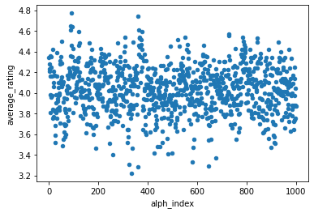

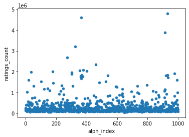

```python
alphabeticalByFirstName = top1000BooksSince1800.sort_values('authors')
alphabeticalByFirstName["alph_index"] = alphabeticalByFirstName.reset_index().index
alphabeticalByFirstName.plot.scatter(x = 'alph_index', y = "average_rating")
alphabeticalByFirstName.plot.scatter(x = 'alph_index', y = "ratings_count")
```

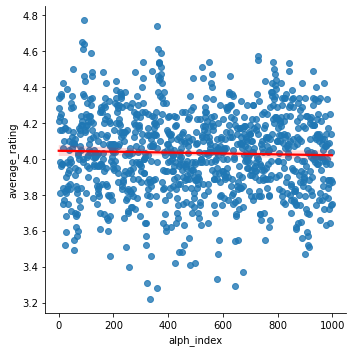

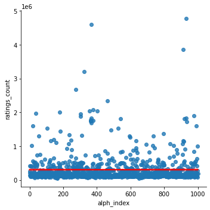

```python
import seaborn as sns
sns.lmplot(x='alph_index', y='average_rating',data=alphabeticalByFirstName, fit_reg=True, line_kws={'color': 'red'})
sns.lmplot(x='alph_index', y='ratings_count',data=alphabeticalByFirstName, fit_reg=True, line_kws={'color': 'red'})
```

```python
singleAuthorBooksSince1800 = top1000BooksSince1800.loc[top1000BooksSince1800["authors"].str.contains(",") == False]
singleAuthorBooksSince1800
```

|  | book_id | books_count | authors | original_publication_year | original_title | title | language_code | average_rating | ratings_count | work_ratings_count | work_text_reviews_count | ratings_1 | ratings_2 | ratings_3 | ratings_4 | ratings_5 |
| --- | --- | --- | --- | --- | --- | --- | --- | --- | --- | --- | --- | --- | --- | --- | --- | --- |
| 0 | 1 | 272 | Suzanne Collins | 2008.0 | The Hunger Games | Hunger Games (Hunger Games, #1) | eng | 4.34 | 4780653 | 4942365 | 155254 | 66715 | 127936 | 560092 | 1481305 | 2706317 |
| 2 | 3 | 226 | Stephenie Meyer | 2005.0 | Twilight | Twilight (Twilight, #1) | en-US | 3.57 | 3866839 | 3916824 | 95009 | 456191 | 436802 | 793319 | 875073 | 1355439 |
| 3 | 4 | 487 | Harper Lee | 1960.0 | To Kill a Mockingbird | To Kill a Mockingbird | eng | 4.25 | 3198671 | 3340896 | 72586 | 60427 | 117415 | 446835 | 1001952 | 1714267 |
| 4 | 5 | 1356 | F. Scott Fitzgerald | 1925.0 | The Great Gatsby | Great Gatsby | eng | 3.89 | 2683664 | 2773745 | 51992 | 86236 | 197621 | 606158 | 936012 | 947718 |
| 5 | 6 | 226 | John Green | 2012.0 | The Fault in Our Stars | Fault in Our Stars | eng | 4.26 | 2346404 | 2478609 | 140739 | 47994 | 92723 | 327550 | 698471 | 1311871 |
| ... | ... | ... | ... | ... | ... | ... | ... | ... | ... | ... | ... | ... | ... | ... | ... | ... |
| 1023 | 1024 | 85 | Alan Bradley | 2009.0 | The Sweetness at the Bottom of the Pie | Sweetness at the Bottom of the Pie (Flavia de ... | eng | 3.81 | 99841 | 109533 | 13444 | 2908 | 7650 | 26956 | 42394 | 29625 |
| 1024 | 1025 | 38 | Donald Miller | 2003.0 | Blue Like Jazz: Nonreligious Thoughts on Chris... | Blue Like Jazz: Nonreligious Thoughts on Chris... | en-US | 3.92 | 82090 | 83060 | 3546 | 2857 | 5382 | 16699 | 28410 | 29712 |
| 1025 | 1026 | 59 | Diana Gabaldon | 2005.0 | A Breath of Snow and Ashes | A Breath of Snow and Ashes (Outlander, #6) | eng | 4.43 | 87098 | 102765 | 4053 | 439 | 1712 | 10717 | 30762 | 59135 |
| 1026 | 1027 | 64 | Rick Riordan | 2014.0 | The Blood of Olympus | Blood of Olympus (Heroes of Olympus, #5) | eng | 4.41 | 110719 | 125962 | 12234 | 822 | 2457 | 13295 | 36585 | 72803 |
| 1027 | 1028 | 45 | Liane Moriarty | 2016.0 | Truly Madly Guilty | Truly Madly Guilty | eng | 3.55 | 90477 | 116339 | 11983 | 2752 | 10961 | 41045 | 42953 | 18628 |

786 rows × 16 columns

```python
pd.options.mode.chained_assignment = None

surnames = pd.Series(singleAuthorBooksSince1800["authors"], dtype="string")
singleAuthorBooksSince1800["author_surname"] = surnames

singleAuthorBooksSince1800["author_surname"] = singleAuthorBooksSince1800["author_surname"].str.split().str[-1]
singleAuthorBooksSince1800["author_surname"]
```

```
0          Collins
2            Meyer
3              Lee
4       Fitzgerald
5            Green
           ...
1023       Bradley
1024        Miller
1025      Gabaldon
1026       Riordan
1027      Moriarty
Name: author_surname, Length: 786, dtype: object
```

[figure not shown]

[figure not shown]

```python
alphabeticalBySurname = singleAuthorBooksSince1800.sort_values('author_surname')
alphabeticalBySurname["alph_index"] = alphabeticalBySurname.reset_index().index
alphabeticalBySurname.plot.scatter(x = 'alph_index', y = "average_rating")
alphabeticalBySurname.plot.scatter(x = 'alph_index', y = "ratings_count")
```

[figure not shown]

[figure not shown]

```python
sns.lmplot(x='alph_index', y='average_rating',data=alphabeticalBySurname, fit_reg=True, line_kws={'color': 'red'})
sns.lmplot(x='alph_index', y='ratings_count',data=alphabeticalBySurname, fit_reg=True, line_kws={'color': 'red'})
```

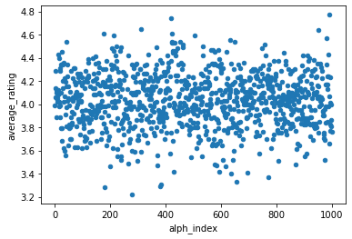

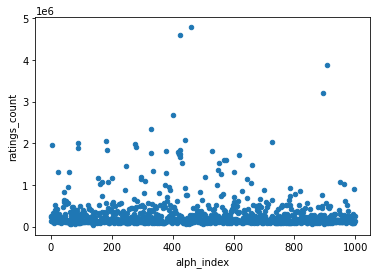

```python
alphabeticalByTitle = top1000BooksSince1800
alphabeticalByTitle['title'] = alphabeticalByTitle['title'].str.replace('The ','')
alphabeticalByTitle = alphabeticalByTitle.sort_values('title')
alphabeticalByTitle["alph_index"] = alphabeticalByTitle.reset_index().index

alphabeticalByTitle.plot.scatter(x = 'alph_index', y = "average_rating")
alphabeticalByTitle.plot.scatter(x = 'alph_index', y = "ratings_count")
```

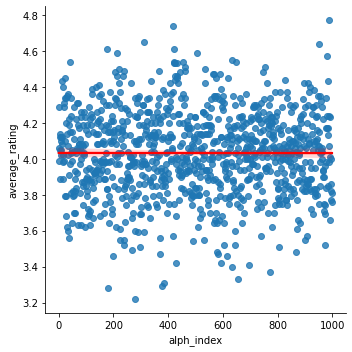

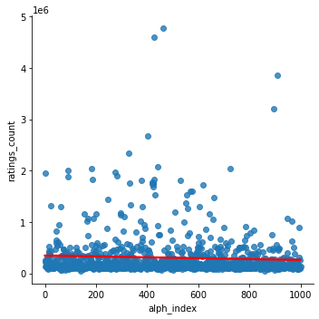

```python
sns.lmplot(x='alph_index', y='average_rating',data=alphabeticalByTitle, fit_reg=True, line_kws={'color': 'red'})
sns.lmplot(x='alph_index', y='ratings_count',data=alphabeticalByTitle, fit_reg=True, line_kws={'color': 'red'})
```

### More Results

Once again, no significant relationship between these variables was found. This is not necessarily discouraging, as it simply means that for this particular dataset, this particular analysis will never have to be repeated again, as the results are now known, thereby saving Data Scientists' time and satisfying the curiosity of those interested in this topic.

```python
r
```

|  | user_id | book_id | rating |
| --- | --- | --- | --- |
| 0 | 1 | 258 | 5 |
| 1 | 2 | 4081 | 4 |
| 2 | 2 | 260 | 5 |
| 3 | 2 | 9296 | 5 |
| 4 | 2 | 2318 | 3 |
| ... | ... | ... | ... |
| 5976474 | 49925 | 510 | 5 |
| 5976475 | 49925 | 528 | 4 |
| 5976476 | 49925 | 722 | 4 |
| 5976477 | 49925 | 949 | 5 |
| 5976478 | 49925 | 1023 | 4 |

5976479 rows × 3 columns

```
array([[<AxesSubplot:title={'center':'Average Rating For This User'}>]],
      dtype=object)
```

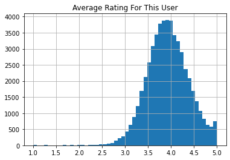

```python
avgRatingPerUser = r.groupby( 'user_id' ).rating.mean()
avgRatingPerUser

userInfo = pd.DataFrame()
userInfo['Average Rating For This User'] = avgRatingPerUser
userInfo['user_ID'] = userInfo.reset_index().index
userInfo.hist(column = "Average Rating For This User", bins = 50)
```

The average ratings for each user appears to be a bell curve with mean and median at roughly 3.9 stars. Next, I was curious about the distribution of number of books rated for each user. I used a histogram to represent this.

```python
userInfo['Num Books Rated'] = r.groupby('user_id').user_id.count()

userInfo.sort_values('Num Books Rated')
```

| user_id | Average Rating For This User | user_ID | Num Books Rated |
| --- | --- | --- | --- |
| 34590 | 4.473684 | 34589 | 19 |
| 43675 | 4.150000 | 43674 | 20 |
| 40753 | 3.428571 | 40752 | 21 |
| 51725 | 3.523810 | 51724 | 21 |
| 32128 | 4.000000 | 32127 | 21 |
| ... | ... | ... | ... |
| 12381 | 3.427136 | 12380 | 199 |
| 28158 | 3.939698 | 28157 | 199 |
| 52036 | 3.442211 | 52035 | 199 |
| 12874 | 3.450000 | 12873 | 200 |
| 30944 | 4.210000 | 30943 | 200 |

53424 rows × 3 columns

```
array([[<AxesSubplot:title={'center':'Num Books Rated'}>]], dtype=object)
```

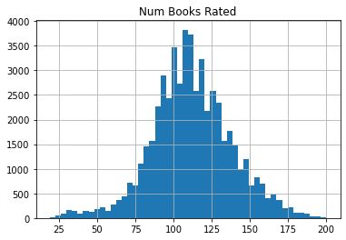

```python
userInfo.hist(column = 'Num Books Rated', bins = 50)
```

Finally, I wanted to check if there was a relationship - on average - between the number of books a user reviewed and their average review. Once again, I used seaborn's lmplot to generate a scatterplot and linear regression line for this.

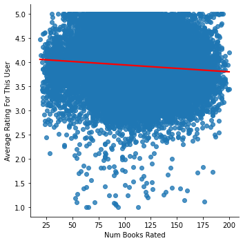

```python
import seaborn as sns
sns.lmplot(x='Num Books Rated', y='Average Rating For This User',data=userInfo, fit_reg=True, line_kws={'color': 'red'})
```

Finally, a slight significant negative relationship could be found between these variables. I believe this relationship exists because the more books a user rates and therefore reads, the more critical and conscious of a book's potential flaws they become.

I then used Seaborn's heatmap function to generate a correlation matrix showing the correlations between all combinations of variables in the dataset.

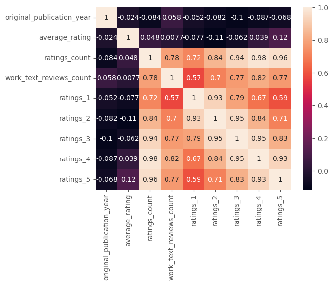

```python
# Source referenced: https://www.geeksforgeeks.org/plotting-correlation-matrix-using-python/


booksSince1800 = b.loc[b["original_publication_year"] > 1800]
booksSince1800 = booksSince1800.drop(columns = ["goodreads_book_id","best_book_id","work_id", "isbn","isbn13","image_url","small_image_url"])
forCorrelationMatrix = booksSince1800
forCorrelationMatrix = forCorrelationMatrix.drop(columns = ['original_title', 'title', 'language_code', 'authors', 'books_count', 'book_id', 'work_ratings_count'])
ax = sns.heatmap(forCorrelationMatrix.corr(), annot=True)
```

```python
booksSince1800InRandomOrder = booksSince1800.sample(frac = 1)
training_df = booksSince1800InRandomOrder.iloc[:7500]
training_df

testing_df = booksSince1800InRandomOrder.iloc[7501:].sort_values(by = 'ratings_5')
```

## Making Predictions about Number of 5-Star Reviews

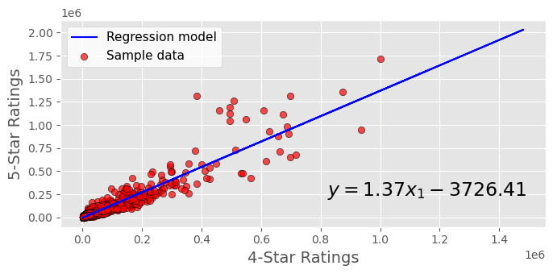

```python
# Source referenced: https://aegis4048.github.io/mutiple_linear_regression_and_visualization_in_python

from sklearn import model_selection
from sklearn import linear_model
from sklearn import preprocessing
import statsmodels.formula.api as smf
import statsmodels.api as sm
import matplotlib.pyplot as plt
import numpy as np

x = training_df['ratings_4'].values.reshape(-1, 1)
y = training_df['ratings_5']

ols = linear_model.LinearRegression()
model = ols.fit(x, y)

# Using the testing data to generate predictions using the linear model generated from the trainin dataset.
x_pred = testing_df['ratings_4']
x_pred = x_pred.values.reshape(-1, 1)
y_pred = model.predict(x_pred)

plt.style.use('default')
plt.style.use('ggplot')

fig, ax = plt.subplots(figsize=(7, 3.5))

ax.plot(x_pred, y_pred, color='b', label='Regression model')
ax.scatter(x, y, edgecolor='k', facecolor='red', alpha=0.7, label='Sample data')
ax.set_ylabel('5-Star Ratings', fontsize=14)
ax.set_xlabel('4-Star Ratings', fontsize=14)
ax.legend(facecolor='white', fontsize=11)
ax.text(0.55, 0.15, '$y = %.2f x_1 - %.2f $' % (model.coef_[0], abs(model.intercept_)), fontsize=17, transform=ax.transAxes)

fig.tight_layout()
```

```python
# The R^2 score, showing the goodness of fit of the model, came out as 0.877, showing that this model is very well
# fitted to the data.
model.score(x, y)
```

```
0.8774702007820979
```

```python
x_pred = np.array(testing_df['ratings_4'])
x_pred = x_pred.reshape(-1, 1)
testing_df['Predicted 5 Star Rating Values'] = model.predict(x_pred)
```

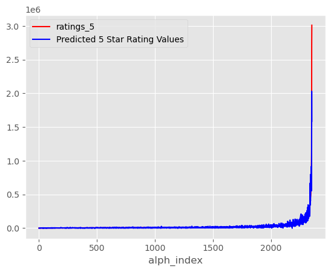

```python
testing_df["alph_index"] = testing_df.reset_index().index

testing_df.plot.line(x = 'alph_index', y = ['ratings_5','Predicted 5 Star Rating Values'], color = ['red','blue'])
```